# Breast cancer detection

Installing Required Packages

```python
pip install opencv-python
```

```python
pip install pandas
```

```
  Using cached pytz-2022.1-py2.py3-none-any.whl (503 kB)
```

```python
pip install matplotlib
```

```python
pip install scikit-learn
```

```
  Using cached joblib-1.1.0-py2.py3-none-any.whl (306 kB)
```

Importing packages

```python
import os
import cv2
import random
import numpy as np
import pandas as pd
import tensorflow as tf
import matplotlib.pyplot as plt
import matplotlib.pyplot as plt
from sklearn.model_selection import train_test_split
```

Load categories of training data

```python
CATEGORIES = pd.read_csv('./mammography_images/Training_set.csv')
```

Print head of categories

```python
CATEGORIES.head()
```

|  | filename | label |
| --- | --- | --- |
| 0 | Image_1.jpg | Density3Benign |
| 1 | Image_2.jpg | Density1Benign |
| 2 | Image_3.jpg | Density1Malignant |
| 3 | Image_4.jpg | Density1Benign |
| 4 | Image_5.jpg | Density1Malignant |

Rename label values to make suitable for tensorflow

```python
mapping = {'Density1Benign':0,
           'Density2Benign':1,
           'Density3Benign':2,
           'Density4Benign':3,
           'Density1Malignant':4,
           'Density2Malignant':5,
           'Density3Malignant':6,
           'Density4Malignant':7}
```

```python
for i in range(len(CATEGORIES['label'])):
    CATEGORIES['label'][i] = mapping[CATEGORIES['label'][i]]
CATEGORIES.head()
```

|  | filename | label |
| --- | --- | --- |
| 0 | Image_1.jpg | 2 |
| 1 | Image_2.jpg | 0 |
| 2 | Image_3.jpg | 4 |
| 3 | Image_4.jpg | 0 |
| 4 | Image_5.jpg | 4 |

Count of distinct labels

```python
category_count = CATEGORIES['label'].nunique()
category_count
```

```
8
```

Path of training images

```python
path = './mammography_images/train'
```

```python
def seggregate_data(training_data):
    X = []
    Y = []
    for features, lables in training_data:
        X.append(features)
        Y.append(lables)
    X = np.array(X)
    Y = np.array(Y)
    return X,Y
```

Load each image from path metioned and label it from categories

```python
training_data =[]
for i in range(len(CATEGORIES['filename'])):
    img_array = cv2.imread(os.path.join(path,CATEGORIES['filename'][i]) , cv2.IMREAD_GRAYSCALE)
    new_array = cv2.resize(img_array,(100,100))
    training_data.append([new_array,CATEGORIES['label'][i]])

features,labels = seggregate_data(training_data)
```

Check shape of sample image

```python
features[0].shape
```

```
(100, 100)
```

```python
labels
```

```
array([2, 0, 4, ..., 5, 0, 2])
```

Plot a sample image to cross verify

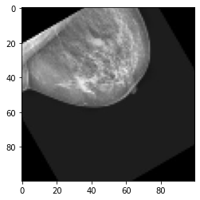

```python
IMG_SIZE = 100
plt.imshow(features.reshape(features.shape[0], IMG_SIZE, IMG_SIZE)[0], cmap ='gray')
plt.show()
```

Training images for each class

BENINGN TUMOUR

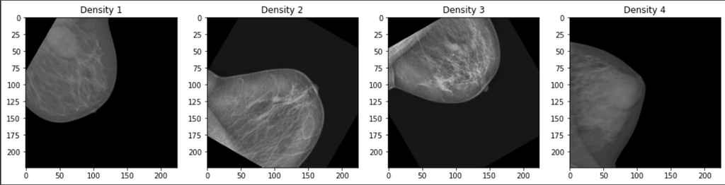

```python
from IPython.display import Image, display

Tumour = ('./image/benign.png')
display(Image(filename=Tumour))
```

MALIGNANT TUMOUR

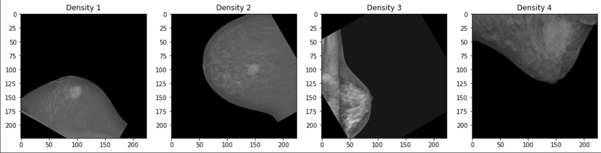

```python
from IPython.display import Image, display

Tumour = ('./image/malignant.png')
display(Image(filename=Tumour))
```

Normalize features and convert labels to categorical for training the model

```python
x_train = features.reshape(features.shape[0], 100, 100, 1)
x_train = x_train.astype('float32')
x_train /= 255
y_train = tf.keras.utils.to_categorical(labels, category_count)
```

Compile model

```python
model = tf.keras.models.Sequential()

model.add(tf.keras.layers.Conv2D(32,(3,3),input_shape=(100,100,1)))
model.add(tf.keras.layers.Dense(32,activation=tf.nn.relu))
model.add(tf.keras.layers.MaxPooling2D(pool_size=(2,2)))

model.add(tf.keras.layers.Conv2D(64, (3,3)))
model.add(tf.keras.layers.Dense(64,activation=tf.nn.relu))
model.add(tf.keras.layers.MaxPooling2D(pool_size=(2,2)))

model.add(tf.keras.layers.Flatten())

model.add(tf.keras.layers.Dropout(0.2))

model.add(tf.keras.layers.Dense(category_count,activation=tf.nn.softmax))

model.compile(optimizer='adam',
                    loss='categorical_crossentropy',
                    metrics=['accuracy'])
```

Train the model compiled above

```python
model.fit(x_train,y_train,epochs=10)
```

```
<keras.callbacks.History at 0x1d4a117fcd0>
```

Image Processing

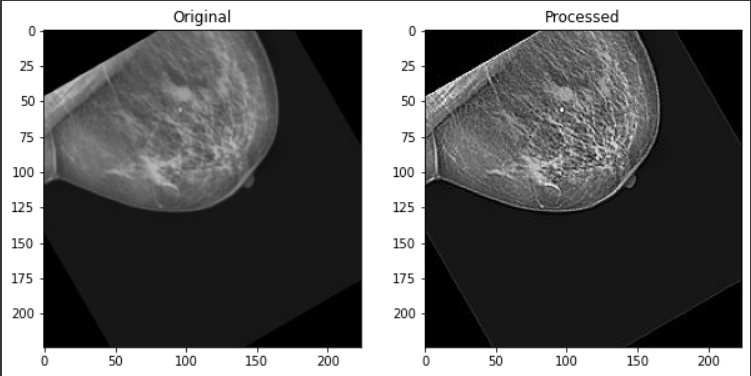

```python
from IPython.display import Image, display

Processed_op = ('./image/processing.png')
display(Image(filename=Processed_op))
```

Load categories of testing data

```python
CATEGORIES_test = pd.read_csv('./mammography_images/Testing_set.csv')
```

Print head of test categories

```python
CATEGORIES_test.head()
```

|  | filename |
| --- | --- |
| 0 | Image_1.jpg |
| 1 | Image_2.jpg |
| 2 | Image_3.jpg |
| 3 | Image_4.jpg |
| 4 | Image_5.jpg |

Path of testing images

```python
path_test = './mammography_images/test'
```

Load each image from path metioned and label it from categories

```python
testing_data =[]
for i in range(len(CATEGORIES_test['filename'])):
    img_array = cv2.imread(os.path.join(path_test,CATEGORIES_test['filename'][i]) , cv2.IMREAD_GRAYSCALE)
    new_array = cv2.resize(img_array,(100,100))
    testing_data.append([new_array])
```

```python
X_test_features = []
for features in testing_data:
    X_test_features.append(features)
X_test_features = np.array(X_test_features)
```

Normalize features for prediction

```python
x_test = X_test_features.reshape(X_test_features.shape[0], 100, 100, 1)
x_test = x_test.astype('float32')
x_test /= 255
```

Predict using prepared testing data

```python
model_predictions=model.predict(x_test)
```

Perform argmax on predicted labels

```python
pred_Categories = []
for i in model_predictions:
    pred_Categories.append(np.argmax(i))
```

Reverse mapping for predicted values

```python
reverse_mapping = {0:'Density1Benign',
           1:'Density2Benign',
           2:'Density3Benign',
           3:'Density4Benign',
           4:'Density1Malignant',
           5:'Density2Malignant',
           6:'Density3Malignant',
           7:'Density4Malignant'}
```

Rename label with actual values for predicted values

```python
predicted_Categories = []
for i in pred_Categories:
    predicted_Categories.append(reverse_mapping[i])
```

Combine predicted labels with filename

```python
CATEGORIES_test['label'] = predicted_Categories
```

Print head of test categories

```python
CATEGORIES_test.head()
```

|  | filename | label |
| --- | --- | --- |
| 0 | Image_1.jpg | Density3Benign |
| 1 | Image_2.jpg | Density1Benign |
| 2 | Image_3.jpg | Density2Malignant |
| 3 | Image_4.jpg | Density1Benign |
| 4 | Image_5.jpg | Density3Malignant |

Save the predicted values to csv file

```python
CATEGORIES_test.to_csv('predicted_values5.csv', sep=',', encoding='utf-8')
```

Display of results

[figure not shown]

```python
from IPython.display import Image, display

Prediction = ('./image/prediction.png')
display(Image(filename=Prediction))
```